# Part annotations preprocessing

Bria Long and Holly Huey

1/4/2022, updated 7/2023

This markdown was written for *kiddraw_annotations* (data originally collected in Long, Fan, Chai, & Frank, 2021). The data and figures of this markdown will be submitted to the CogSci conference 2022.

Note about what happened before this markdown: 1) data collected from the experiment through analysis/step2_generate_metadata/kiddraw_generate_metadata.ipynb

2. data was preprocessed in analysis/step3_analysis/kiddraw_analyses.ipynb — in particular, data sessions were excluded based on low accuracy on the catch trials and we used this notebook to check whether every drawing has responses from at least 3 annotators.

# Preprocessing

## Compute how many images we have more than two annotators

```
## [1] 2160
```

```
## [1] 2160
```

## Look at agreement by label

### Plot agreements

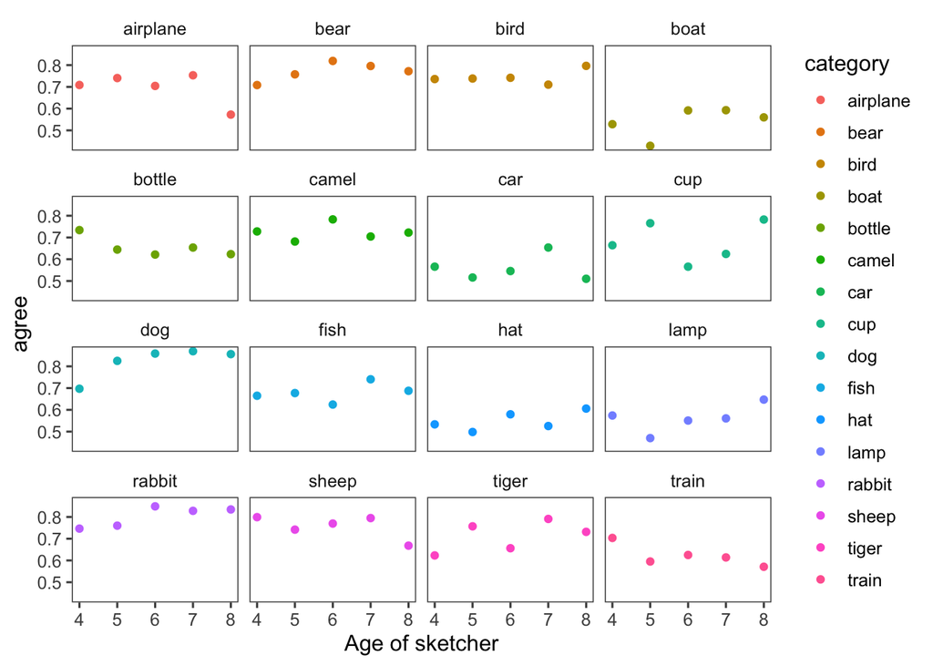

**R version 4.1.3 (2022-03-10)**

**Platform:** x86_64-apple-darwin17.0 (64-bit)

**locale:** en_US.UTF-8||en_US.UTF-8||en_US.UTF-8||C||en_US.UTF-8||en_US.UTF-8

**attached base packages:** *stats*, *graphics*, *grDevices*, *utils*, *datasets*, *methods* and *base*

**other attached packages:** *knitr(v.1.38)*, *tidytext(v.0.3.2)*, *ggthemes(v.4.2.4)*, *lmerTest(v.3.1-3)*, *pander(v.0.6.5)*, *lme4(v.1.1-29)*, *Matrix(v.1.4-0)*, *forcats(v.0.5.1)*, *stringr(v.1.4.0)*, *dplyr(v.1.0.8)*, *purrr(v.0.3.4)*, *readr(v.2.1.2)*, *tidyr(v.1.2.0)*, *tibble(v.3.1.6)*, *ggplot2(v.3.3.5)* and *tidyverse(v.1.3.1)*